# Homework1

Rohan Sadale

Jan 28, 2016

```r
library(alr4)
```

#### 1.1.

**1.1.1**

- Predictor: ppgdp
- Response: fertility

**1.1.2**

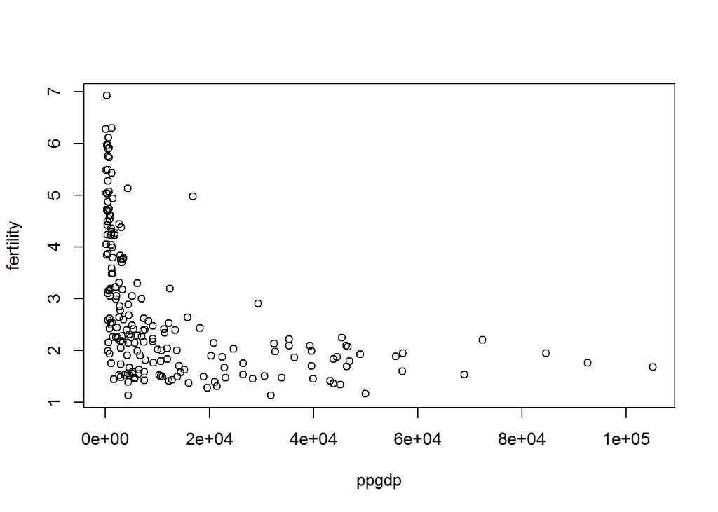

```r
with(UN11, plot(fertility ~ ppgdp))
```

The plot is right skewed. Hence Simple Linear Regression cannot be a good fit for this graph. The straight line mean function is not possible for this graph.

**1.1.3**

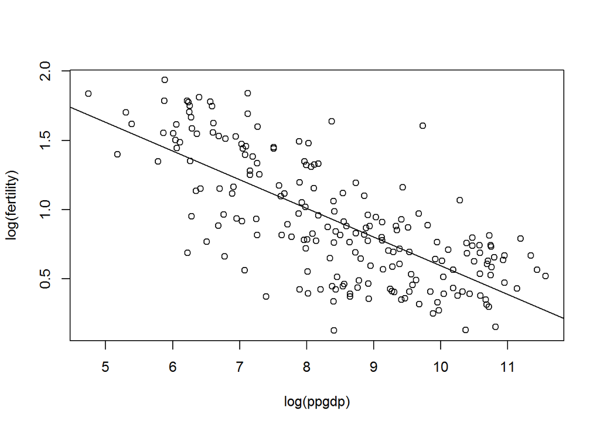

```r
with(UN11, plot(log(fertility) ~ log(ppgdp)))
model <- lm(log(fertility) ~ log(ppgdp), data = UN11)
abline(model)
```

Yes, as we can see from the plot, Simple Linear Regression seem plausible for a summary of this graph.

#### 1.2

```r
meanData <- with(wblake, tapply(Length, Age, mean))
print(meanData)
```

```
##         1         2         3         4         5         6         7
##  98.34211 124.84722 152.56383 193.80000 221.72059 252.59770 269.86885
##         8
## 306.25000
```

```r
varianceData <-with(wblake, tapply(Length, Age, var))
print(varianceData)
```

```
##         1         2         3         4         5         6         7
##  808.2312  697.2862  411.6679  867.4571  985.6969 1105.0805  869.3825
##         8
## 1802.9167
```

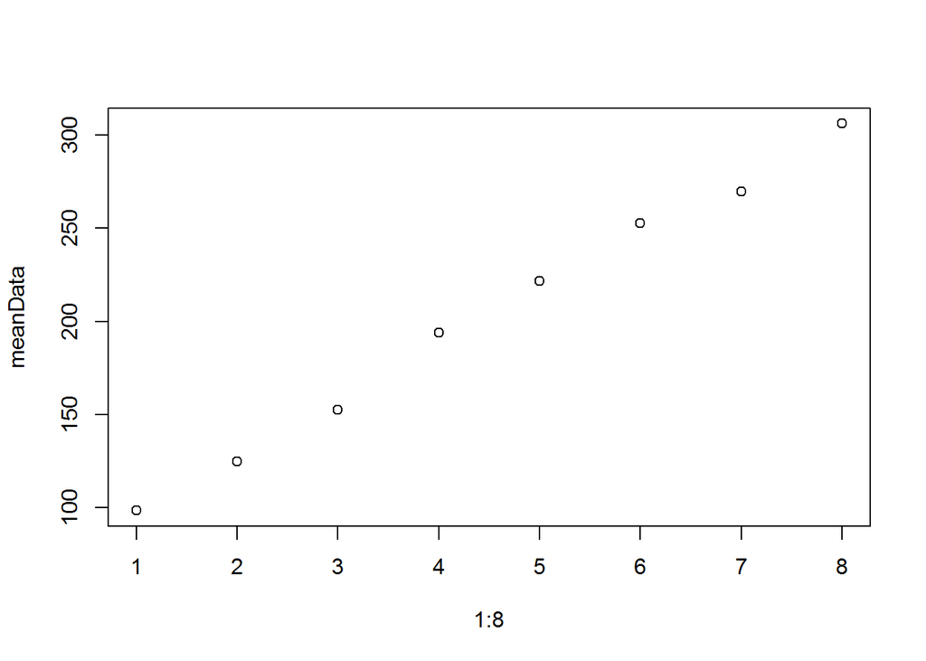

```r
plot(1:8, meanData)
```

The graph shows a rising trend in average length of fish as it grows older, and a simple linear regression seems plausible for this graph. The graph has same pattern as compared to fig 1.5

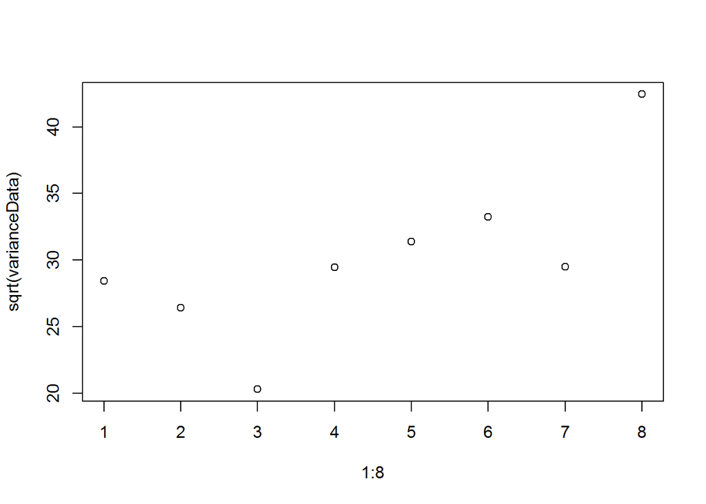

```r
plot(1:8, sqrt(varianceData))
```

Though a straight line parallel to Age axis is possible on the plot, but the variance and standard deviation of the fishes at age 3 and age 8 will deviate significantly from a straight line. Thus, the plot is not a null plot.

#### 1.3

**1.3.1** There appears to be no dependence of average soil temperature on the number of months. The plot appears to be null plot as it doesn’t show any particular important characteristics.

**1.3.2**

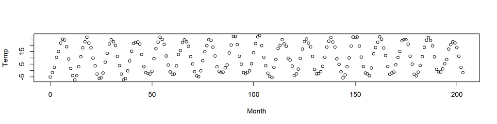

```r
with(Mitchell, plot(Temp~Month))
```

As the width changes, we are able to see a temporal pattern on data. We can say that the soil temperature falls in Winter and rises in summer.

#### 1.4

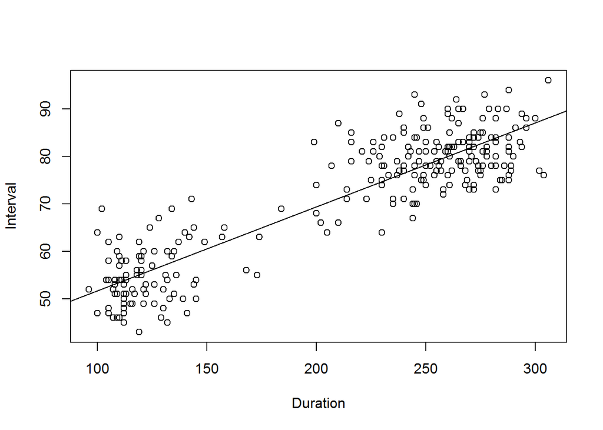

```r
with(oldfaith, plot(Interval~Duration))
model2 <- lm(Interval~Duration, data = oldfaith)
abline(model2)
```

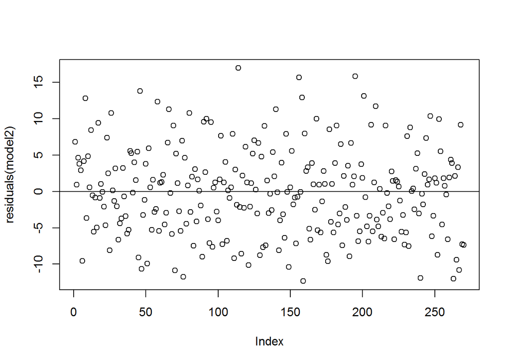

```r
plot(residuals(model2))
abline(0,0)
```

The mean is almost linear, variance is almost constant and the residual plot can be a null plot. Thus, we can summarize the graph by simple linear regression.

#### 1.5

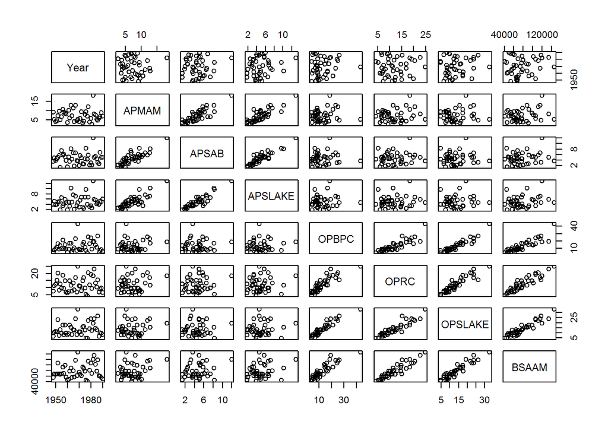

```r
plot(water)
```

- From the plot, we can say that Year is highly uncorelated to all other variables.
- We can also notice that the variables OPBPC, OPRC, OPSLAKE and BSAAM are corelated with each other. Similarly, the variables - APMAM, APSAB and APSLAKE appear to be corelated with each other.
- BSAAM is more corelated with OPBPC, OPRC and OPSLAK, while less corelated with APMAM, APSAB and APSLAKE.
- We can also see that there is atleast one seperated point (outlier or leverage point) in each plot.